# SDS 192: Homework #4

Sabrina Sayasith

Due: 3/11/16

```r
require(mosaic)
```

#### Problem #1

[Gapminder](http://www.gapminder.org/data/) is a terrific resource for data, usually about countries. All of their data exists as Google spreadsheets, which can be loaded directly into R using the `googlesheets` package. For example, the following bit of code loads data about the percentage of adults ages 15-49 who have HIV.

```r
library(googlesheets)
# http://spreadsheets.google.com/pub?key=pyj6tScZqmEfbZyl0qjbiRQ&gid=0
hiv_key <- "pyj6tScZqmEfbZyl0qjbiRQ"
hiv <- gs_key(hiv_key, lookup = FALSE) %>%
  gs_read(ws = "Data", range = cell_limits(c(1, 1), c(276, 34)))
```

```
## Authentication will not be used.
```

```
## Worksheets feed constructed with public visibility
```

```
## Accessing worksheet titled "Data"
```

Note that this data set is in a `wide` format: each row corresponds to a country, and each column corresponds to a year. This is also often called [**panel data**](http://en.wikipedia.org/wiki/Panel_data).

```r
head(hiv)
```

```
## Source: local data frame [6 x 34]
##
##   Estimated.HIV.Prevalence.....Ages.15.49. X1979 X1980 X1981 X1982 X1983
##                                      (chr) (dbl) (dbl) (dbl) (dbl) (dbl)
## 1                                 Abkhazia    NA    NA    NA    NA    NA
## 2                              Afghanistan    NA    NA    NA    NA    NA
## 3                    Akrotiri and Dhekelia    NA    NA    NA    NA    NA
## 4                                  Albania    NA    NA    NA    NA    NA
## 5                                  Algeria    NA    NA    NA    NA    NA
## 6                           American Samoa    NA    NA    NA    NA    NA
## Variables not shown: X1984 (dbl), X1985 (dbl), X1986 (dbl), X1987 (dbl),
##   X1988 (lgl), X1989 (lgl), X1990 (dbl), X1991 (dbl), X1992 (dbl), X1993
##   (dbl), X1994 (dbl), X1995 (dbl), X1996 (dbl), X1997 (dbl), X1998 (dbl),
##   X1999 (dbl), X2000 (dbl), X2001 (dbl), X2002 (dbl), X2003 (dbl), X2004
##   (dbl), X2005 (dbl), X2006 (dbl), X2007 (dbl), X2008 (dbl), X2009 (dbl),
##   X2010 (dbl), X2011 (dbl)
```

We want to plot a time series for a selection of countries. We could do this by selecting the rows individually, but this would be a clunky solution that would not scale if we wanted to plot many countries. The solution is to `gather` the data from into a `long` format.

1. Gather the `hiv` data frame into long format and store that as a new `data.frame`. Your result should have only four columns: `country`, `year`, and `hiv_rate`.

```r
require(tidyr)
longHiv <- hiv %>%
  gather(key = year, value = hiv_rate, -Estimated.HIV.Prevalence.....Ages.15.49.)

head(longHiv)
```

```
## Source: local data frame [6 x 3]
##
##   Estimated.HIV.Prevalence.....Ages.15.49.  year hiv_rate
##                                      (chr) (chr)    (dbl)
## 1                                 Abkhazia X1979       NA
## 2                              Afghanistan X1979       NA
## 3                    Akrotiri and Dhekelia X1979       NA
## 4                                  Albania X1979       NA
## 5                                  Algeria X1979       NA
## 6                           American Samoa X1979       NA
```

```r
dim(longHiv)
```

```
## [1] 9075    3
```

> Note: Do **NOT** display the whole data frame. Just show the `head` and the `dim`ensions!!

```r
require(tidyr)
```

2. R does not allow column names to start with numbers. That is why the variable names are all of the form “X1978” and so on. Use the function `extract_numeric` to remove the X’sand force R to see the `year` column as a numeric vector instead of a character vector. Demonstrate that your solution works by taking the `range` of the `year` variable.

```r
longHivYears <- longHiv[[2]] %>%
  extract_numeric()

longHiv[[2]] = longHivYears
head(longHiv)
```

```
## Source: local data frame [6 x 3]
##
##   Estimated.HIV.Prevalence.....Ages.15.49.  year hiv_rate
##                                      (chr) (dbl)    (dbl)
## 1                                 Abkhazia  1979       NA
## 2                              Afghanistan  1979       NA
## 3                    Akrotiri and Dhekelia  1979       NA
## 4                                  Albania  1979       NA
## 5                                  Algeria  1979       NA
## 6                           American Samoa  1979       NA
```

```r
range(longHiv[2])
```

```
## [1] 1979 2011
```

3. Find the subset of the data that pertains only to HIV rates for the United States, Ghana, Liberia, and South Africa, since 1990.

```r
longHiv <- longHiv %>%
  filter(year >= 1990) %>%
  filter (Estimated.HIV.Prevalence.....Ages.15.49. %in% c("Ghana", "United States", "Liberia", "South Africa"))

head(longHiv)
```

```
## Source: local data frame [6 x 3]
##
##   Estimated.HIV.Prevalence.....Ages.15.49.  year hiv_rate
##                                      (chr) (dbl)    (dbl)
## 1                                    Ghana  1990      0.3
## 2                                  Liberia  1990      0.3
## 3                             South Africa  1990      0.7
## 4                            United States  1990      0.5
## 5                                    Ghana  1991      0.4
## 6                                  Liberia  1991      0.5
```

4. Create a time series plot of HIV rate since 1990 for those four countries, and add a key to the plot. What do you observe about HIV rates in these countries?

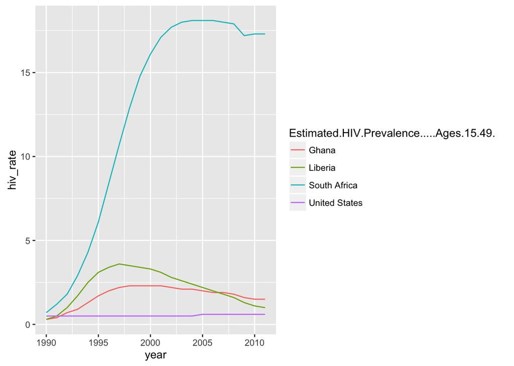

```r
hivRates <- ggplot(data = longHiv, aes(x = year, y = hiv_rate, colour = Estimated.HIV.Prevalence.....Ages.15.49.))
hivRates + geom_line()
```

The HIV rate in South Africa increased rapidly and dramatically from 1990 to 2002. From 2003 to 2011, the HIV rate of South Africa stagnated. The HIV rate in the United States has been stagnant over the same time frame and hasn’t changed much at all. The HIV rate in the US is dramatically lower than the HIV rate in South Africa. Liberia and Ghana have HIV rates that rose quickly from 1990 to 1997, but then their rates started falling at a steady pace from 2000 onward.

#### Problem #2

Once again, we’ll be using the 2012 airlines data from Bradley airport.

```r
# devtools::install_github("beanumber/mdsr")
require(mdsr)
bdl <- src_scidb("airlines") %>%
  tbl("flights") %>%
  filter(year == 2012) %>%
  filter((dest == "BDL" | origin == "BDL")) %>%
  collect()
```

1. Write a function `getFlights()` that will determine, for a given airport code, the number of distinct flight numbers (e.g. `flight` – not the number of flights!) that fly into **and** out of Bradley. Your function should take two arguments: a data frame called `data` and `code`, which is the three character airport code. **It should return a data.frame with two columns and one row**. The first column should be called `incoming` and give the number of distinct flight numbers that come into Bradley from that airport. The second column should be called `outgoing` and give the number of distinct flight numbers that come out of Bradley to that airport.

Your output should look like this:

```r
getFlights(data = bdl, code = "DFW")
```

```
## incoming outgoing
##        8       14
```

```r
#input: data, airport code
getFlights <- function(data, code){

  dataOrigin <- data %>%
    filter(origin == code)%>%
    select(flight) %>%
    unique()

  dataDest <- data %>%
    filter(dest == code) %>%
    select(flight) %>%
    unique()

  incoming = c(nrow(dataOrigin))
  outgoing = c(nrow(dataDest))
  df = data.frame(incoming, outgoing)
  df


}

getFlights(bdl, "DFW")
```

```
##   incoming outgoing
## 1        8       14
```

2. The three New York metro airports are JFK, LaGuardia (LGA), and Newark (EWR). Use `sapply()` and your answer to the previous problem to find the number of distinct incoming and outgoing flights to and from these airports.

> Note: It is not necessary, but you may want to take the transpose of the output from `sapply()`. To do this, simply wrap the call to `sapply()` with `t()`. The transpose function `t()` simply converts an $n \times k$ matrix into a $k \times n$ matrix.

```r
#JFK, LGA, EWR
codes <- c("JFK", "LGA", "EWR")
dataArg <- c(bdl)
t(sapply(codes, getFlights, data = bdl))
```

```
##     incoming outgoing
## JFK 0        1
## LGA 1        0
## EWR 53       81
```

3. Now perform the same operation, but using `lapply()` instead of `sapply()`. What is the data type of the result from `lapply()`? What about `sapply()`? Comment on the usefulness of the result from `sapply()` as opposed to `lapply()`.

```r
lapply(codes, getFlights, data = bdl)
```

```
## [[1]]
##   incoming outgoing
## 1        0        1
##
## [[2]]
##   incoming outgoing
## 1        1        0
##
## [[3]]
##   incoming outgoing
## 1       53       81
```

4. Cast the matrix returned by `sapply()` into a data frame by calling `as.data.frame()`. Also, add the row names as a new variable. You can access the row names with `rownames()`.

```r
dfSapply = as.data.frame(sapply(codes, getFlights, data = bdl))
dfSapply <- dfSapply %>%
  mutate(Type = rownames(dfSapply))
dfSapply
```

```
##   JFK LGA EWR     Type
## 1   0   1  53 incoming
## 2   1   0  81 outgoing
```

5. Note that the `data.frame` has a strange structure. Use `str()` to display the structure. It should be a `data.frame` of `list`s!

```r
str(dfSapply)
```

```
## 'data.frame':    2 obs. of  4 variables:
##  $ JFK :List of 2
##   ..$ incoming: int 0
##   ..$ outgoing: int 1
##  $ LGA :List of 2
##   ..$ incoming: int 1
##   ..$ outgoing: int 0
##  $ EWR :List of 2
##   ..$ incoming: int 53
##   ..$ outgoing: int 81
##  $ Type: chr  "incoming" "outgoing"
```

6. Use `unnest()` to melt the lists away, leaving a normal-looking `tbl_df`.

```r
dfSapply <-dfSapply %>%
  unnest()
dfSapply
```

```
## Source: local data frame [2 x 4]
##
##       Type   JFK   LGA   EWR
##      (chr) (int) (int) (int)
## 1 incoming     0     1    53
## 2 outgoing     1     0    81
```

6. Make the `tbl_df` you created in the previous problem **tidy**.

```r
dfSapply <- dfSapply %>%
  gather(key = "Airport", value = "# of Flights", -Type)

dfSapply
```

```
## Source: local data frame [6 x 3]
##
##       Type Airport # of Flights
##      (chr)   (chr)        (int)
## 1 incoming     JFK            0
## 2 outgoing     JFK            1
## 3 incoming     LGA            1
## 4 outgoing     LGA            0
## 5 incoming     EWR           53
## 6 outgoing     EWR           81
```

#### Bonus

Repeat the previous problem, but for all airports instead of just three. Make an appropriate data graphic for displaying the resulting data.